# Project

Benjámin Olivér Maday

### Introduction

Whith the advent of ChatGPT jobs that were previously considered not being under the threat of getting replaced by machines seem to be under attack. Now that AI is coming even for white collar workplaces, a lot of people still think that the personal touch, that only a human could give can not be replaced. Before starting this project, I found myself talking to someone who happens to have such an irreplacable profession: an HR assistant. As it is customary between a person working in human resources, and someone studying an IT related field we engaged in a teasing conversation in which why tried to prove how the other's profession was actually useless. In this project I would like to elaborate on that exact point, hovewer not so bluntly. I would like to find an application for our learned methods in a domain which one wouldn't really associate with machine learning, and maybe (just maybe), win a bet which a might or might not have made during the course of the aforementioned conversation.

```python
import matplotlib.pyplot as plt
import seaborn as sns
import pandas as pd
import numpy as np
from sklearn.model_selection import train_test_split;
from sklearn.preprocessing import StandardScaler;
from sklearn.metrics import mean_squared_error, r2_score;
from sklearn.linear_model import LinearRegression;
from pygam import LogisticGAM, LinearGAM, s,l, te, GAM, terms
import warnings;
from sklearn import datasets
from sklearn.svm import SVC
from sklearn.metrics import classification_report, roc_auc_score
from patsy import dmatrix
from sklearn.ensemble import RandomForestRegressor, AdaBoostRegressor, GradientBoostingRegressor
from sklearn.model_selection import RandomizedSearchCV
from sklearn.metrics import confusion_matrix
from sklearn.ensemble import RandomForestClassifier, GradientBoostingClassifier
from sklearn.model_selection import GridSearchCV
from sklearn.metrics import accuracy_score, precision_score, recall_score, f1_score
```

## Exploratory data analysis

After looking through a few online machine learning databases I found a dataset with which I can illustrate my abovementioned goal, that even HR processes can be helped and improved, with data science. The database <sup>1</sup> is from a Aman Kharwal article on The Clever Programmer blog <sup>2</sup>. I applied a few ideas from the article in preprocessing, but I did not use it afterwards. The dataset is something that one could call a very basic HR records. It contains fundamental information about 14999 employees, including whether they left the company or not. I would like to use this information to predict fluctuation within our workforce, and to determine key reasons for someone to leave the company (for example pay or work schedule). The features I am using to determine employee turnover are:

| Variable | Description |
| --- | --- |
| satisfaction_level | The level of an individual's subjective satisfaction at the company |
| last evaluation | The same information at the last evaluation of satisfaction levels. The values are higher, since those who had low values are likely to have already left the company |
| number project | Number of projects an individual is involved in |
| average monthly hours | The number of hours someone works in a month |

Since department and salary are given as factors, I converted them into dummy variables. I couldn't find any missing data, so I didn't use any methods to address it. A few variables are measured on different scales, which could lead to false conclusions when discussing the factors leading to resignations, therefore I scaled the input data.

```python
hr = pd.read_csv('datasets_9768_13874_HR_comma_sep.csv')
hr=hr.rename(columns = {'sales':'department'})

dummies_department = pd.get_dummies(hr['department'], prefix = 'department')
hr1=hr.join(dummies_department)
hr=hr1

dummies_salary = pd.get_dummies(hr['salary'], prefix = 'salary')
hr1=hr.join(dummies_salary)
hr=hr1

hr.drop(hr.columns[[8, 9]], axis=1, inplace=True)
hr_vars=hr.columns.values.tolist()
y=hr['left']
feature=hr
feature = feature.drop(columns=['left'])
```

```python
scaler = StandardScaler()
columns_to_scale = feature.iloc[:, 2:5]
scaled_columns = scaler.fit_transform(columns_to_scale)
X_scaled = feature.copy() #why is python so weird??
X_scaled.iloc[:, 2:5] = scaled_columns
```

When we visualise the output variable, we can see that the amount of people who left the company is a considerably smaller than that of those who stayed. The ratio is not terrible, nonetheless we should take it into account when we are evaluating the results

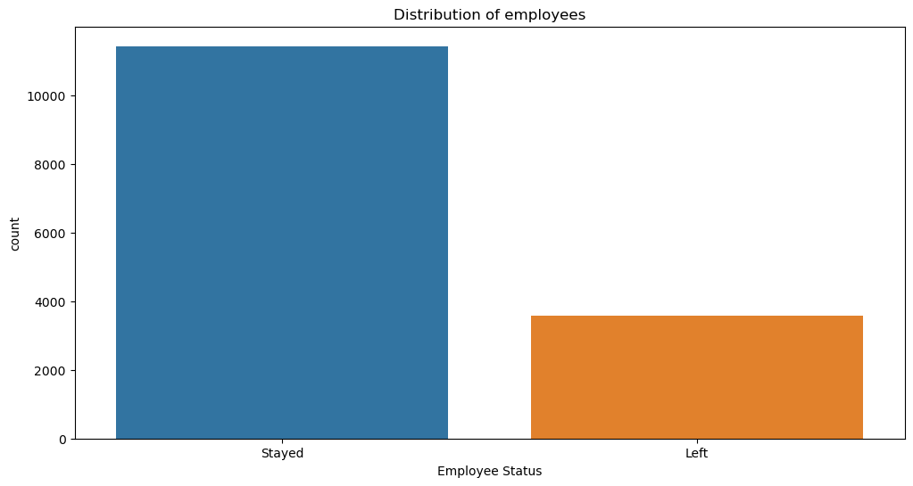

```python
# Visualizing the distribution of classes
plt.figure(figsize=(12, 6))
sns.countplot(x='left', data=hr)
plt.xticks(ticks=[0, 1], labels=['Stayed', 'Left'])
plt.xlabel('Employee Status')
plt.title('Distribution of employees')
plt.show()
```

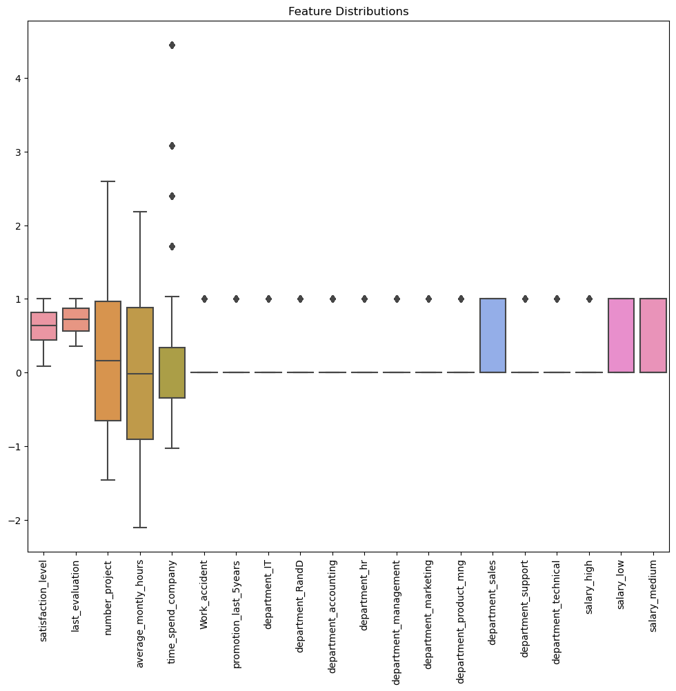

```python
plt.figure(figsize=(12, 10))
sns.boxplot(data=X_scaled)  # Specify the 'data' parameter
plt.xticks(rotation=90)
plt.title('Feature Distributions')
plt.show()
```

```python
filtering = ~(X_scaled.iloc[:, 4] > 1.5)
X_scaled = X_scaled[filtering]
```

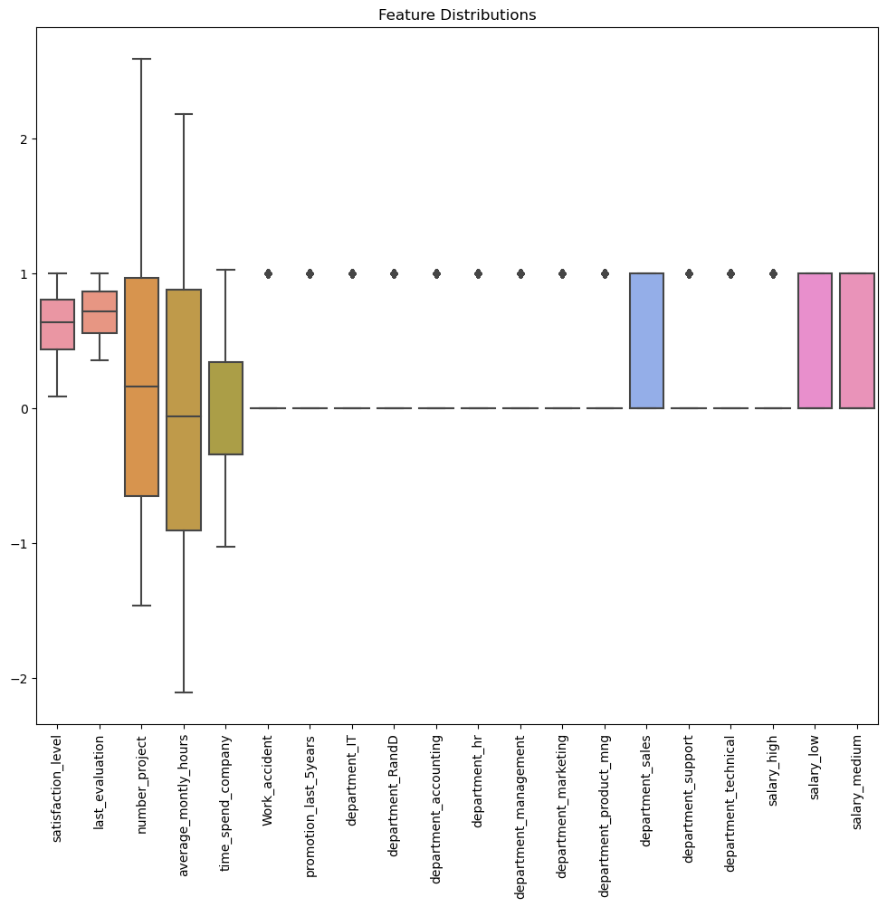

```python
plt.figure(figsize=(12, 10))
sns.boxplot(data=X_scaled)  # Specify the 'data' parameter
plt.xticks(rotation=90)
plt.title('Feature Distributions')
plt.show()
```

[figure not shown]

```python
# Perform correlation analysis
correlation_matrix = hr.corr()

# Plotting the correlation matrix
plt.figure(figsize=(15, 15))
sns.heatmap(correlation_matrix, annot=False, cmap='coolwarm')
plt.title('Correlation Matrix of Breast Cancer Wisconsin (Diagnostic) Features')
plt.show()
```

```python
# Train-test split
y = y[filtering]

X_train, X_test, y_train, y_test = train_test_split(X_scaled, y, test_size=0.3, random_state=42)
```

## Support Vector Machine

As my first model I am going to use a support vector machine. It is a supervised machine learning algorithm primarily used for classification tasks. Since we observed that there is no correlation between the features and the target variable, it is safe to assume that either polynomial or radial basis kernels will be the more accurate ones. If we take a look at the following table which shows the best kernels' results we can see that the RBF is the best function to use by a small margin.

```python
best_models = {}

for kernel in ['linear', 'poly', 'rbf']:
    best_accuracy = 0
    for i in range(1, 20):
        svm = SVC(kernel=kernel, C=i)
        svm.fit(X_train, y_train)
        y_pred = svm.predict(X_test)
        accuracy = svm.score(X_test, y_test)

        # Calculate other metrics
        precision, recall, f1, _ = classification_report(y_test, y_pred, output_dict=True)['weighted avg'].values()
        roc_auc = roc_auc_score(y_test, y_pred)

        # Update best model for the current kernel type
        if accuracy > best_accuracy:
            best_accuracy = accuracy
            best_models[kernel] = {
                'C': i,
                'Kernel': kernel,
                'Accuracy': accuracy,
                'Precision': precision,
                'Recall': recall,
                'F1 Score': f1,
                'ROC-AUC': roc_auc
            }

# Create a DataFrame to display the results
results_df = pd.DataFrame(best_models.values())
results_df.set_index('Kernel', inplace=True)
```

```python
print("Best Models for each Kernel type, C between 1 and 20:")
print(results_df)
```

```
Best Models for each Kernel type, C between 1 and 20:
         C  Accuracy  Precision    Recall  F1 Score   ROC-AUC
Kernel
linear   2  0.842566   0.845202  0.842566  0.843753  0.797241
poly    16  0.961856   0.961701  0.961856  0.961762  0.946527
rbf     19  0.966472   0.966267  0.966472  0.966234  0.948293
```

C is a regularization parameter that controls the trade-off between maximizing the margin and minimizing the classification error. Since 19 is quite close to the maximum value of 20 that I allowed for the model I tried to experiment with higher values, which can be seen on the following graph. It seems like at 26 it reaches a plateu and can't get any higher accuracy than that, and since a lower C will presumably perform better on new data, than one with the same accuracy but higher value (due to possible overfitting on the training data), I choose this as my final SVM model.

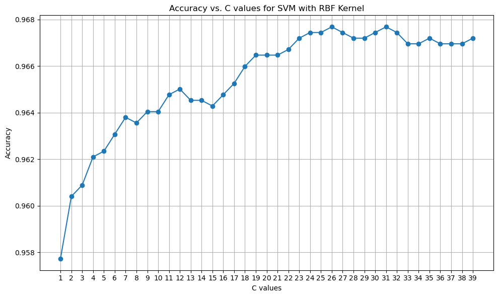

```python
c_values = []
accuracies = []
for i in range(1, 40):
    svm = SVC(kernel='rbf', C=i)
    svm.fit(X_train, y_train)
    y_pred = svm.predict(X_test)
    accuracy = svm.score(X_test, y_test)


    c_values.append(i)
    accuracies.append(accuracy)

plt.figure(figsize=(10, 6))
plt.plot(c_values, accuracies, marker='o', linestyle='-')
plt.title('Accuracy vs. C values for SVM with RBF Kernel')
plt.xlabel('C values')
plt.ylabel('Accuracy')
plt.xticks(c_values)
plt.grid(True)
plt.tight_layout()
plt.show()
```

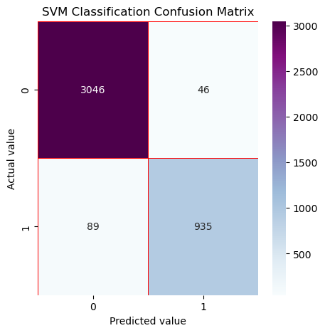

```python
svm = SVC(kernel='rbf', C=26)
svm.fit(X_train, y_train)
svmcla_cm = confusion_matrix(y_test, y_pred)
f, ax = plt.subplots(figsize=(5,5))
sns.heatmap(svmcla_cm, annot=True, linewidth=0.7, linecolor='red', fmt='g', ax=ax, cmap="BuPu")
plt.title('SVM Classification Confusion Matrix')
plt.xlabel('Predicted value')
plt.ylabel('Actual value')
plt.show()
```

I also mapped out the importance of individual features. The department and average monthly hours do not seem to have a significant effect on the turnover rate, except for the IT and RandD departments. Excluding the departments from the model did not result in better predictions, thus I decided to leave them in for the future models as well. There are of course a few obvious findings: a high salary and satisfaction level or a recent promotion keeps people longer at the company. People who had a recent accident are also hesitant to quit, likely due to the settlement payments or bad employability options. What I found interesting, is that people who have spent more time working here are more likely to quit. I have a few hypothesies on what could be behind that (retirement age or end of typical position periods without a promotion), but I would need more information to determine that.

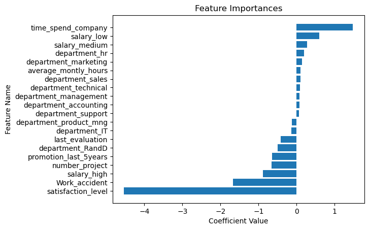

```python
def f_importances(coef, names):
    imp = coef
    imp, names = zip(*sorted(zip(imp, names)))
    plt.barh(range(len(names)), imp, align='center')
    plt.yticks(range(len(names)), names)
    plt.xlabel('Coefficient Value')
    plt.ylabel('Feature Name')
    plt.title('Feature Importances')
    plt.show()


svm = SVC(kernel='linear', C=2.0)
svm.fit(X_train, y_train)
X_train_df = pd.DataFrame(X_train)
feature_names = X_train_df.columns.tolist()
importances = pd.Series(svm.coef_[0], index=feature_names)
f_importances(svm.coef_[0], feature_names)
```

```python
# X_scaled_2 = X_scaled.iloc[:,:6]

# X_train_2, X_test_2, y_train, y_test = train_test_split(X_scaled_2, y, test_size=0.3, random_state=42)
# c_values = []
# accuracies = []
# for i in range(1, 40):
#     svm = SVC(kernel='rbf', C=i)
#     svm.fit(X_train_2, y_train)
#     y_pred = svm.predict(X_test_2)
#     accuracy = svm.score(X_test_2, y_test)


#     c_values.append(i)
#     accuracies.append(accuracy)

# plt.figure(figsize=(10, 6))
# plt.plot(c_values, accuracies, marker='o', linestyle='-')
# plt.title('Accuracy vs. C values for SVM with RBF Kernel')
# plt.xlabel('C values')
# plt.ylabel('Accuracy')
# plt.xticks(c_values)
# plt.grid(True)
# plt.tight_layout()
# plt.show()
```

## Advanced decision tree

For my second model I will experiment with two ensemble methods, using random forest and gradient boosting. The former builds multiple trees by resampling the training data with replacement and fitting a tree to each resampled dataset. In the end it creates a sort of "voting" between these random trees given the new input data, to arrive at a conclusion about the prediction. The latter is also a collection of trees, but it builds them in a sequential order, always improving the tree that came before, finally arriving at the best one. Random forest in this case seems to yield the better results, with a whopping 0.988 accuracy.

```python
# Random Forest
rf = RandomForestClassifier(random_state=42)
rf_params = {
    'n_estimators': [100, 200],
    'max_depth': [5, 10, None]
}
rf_grid = GridSearchCV(rf, rf_params, cv=5)
rf_grid.fit(X_train, y_train)
rf_best = rf_grid.best_estimator_
y_pred_rf = rf_best.predict(X_test)

# Gradient Boosting
gb = GradientBoostingClassifier(random_state=42)
gb_params = {
    'n_estimators': [100, 200],
    'learning_rate': [0.01, 0.1, 0.2],
    'max_depth': [3, 5]
}
gb_grid = GridSearchCV(gb, gb_params, cv=5)
gb_grid.fit(X_train, y_train)
gb_best = gb_grid.best_estimator_
y_pred_gb = gb_best.predict(X_test)

# Metrics
rf_metrics = {
    'Accuracy': accuracy_score(y_test, y_pred_rf),
    'Precision': precision_score(y_test, y_pred_rf),
    'Recall': recall_score(y_test, y_pred_rf),
    'F1 Score': f1_score(y_test, y_pred_rf),
    'ROC-AUC': roc_auc_score(y_test, y_pred_rf)
}

gb_metrics = {
    'Accuracy': accuracy_score(y_test, y_pred_gb),
    'Precision': precision_score(y_test, y_pred_gb),
    'Recall': recall_score(y_test, y_pred_gb),
    'F1 Score': f1_score(y_test, y_pred_gb),
    'ROC-AUC': roc_auc_score(y_test, y_pred_gb)
}

results = {'Random Forest': rf_metrics, 'Gradient Boosting': gb_metrics}
pd.DataFrame(results)
```

|  | Random Forest | Gradient Boosting |
| --- | --- | --- |
| Accuracy | 0.988338 | 0.985666 |
| Precision | 0.991935 | 0.983952 |
| Recall | 0.960938 | 0.958008 |
| F1 Score | 0.976190 | 0.970807 |
| ROC-AUC | 0.979175 | 0.976417 |

If we take a look at the confusion matrix it is easy to see that our random forest model is considerably better suited for the task then SVM was. We identified a lot more employees who ended up quitting, meaning we can be much more effective at preventing that in the future, or at least anticipate that.

[figure not shown]

```python
conf_matrix_rf = confusion_matrix(y_test, y_pred_rf)
plt.figure(figsize=(8, 6))
sns.heatmap(conf_matrix_rf, annot=True, fmt='d', cmap='Blues', cbar=False,
            xticklabels=['Stay', 'Left'],
            yticklabels=['Stay', 'Left'])
plt.title('SVM Classification Confusion Matrix')
plt.xlabel('Predicted value')
plt.ylabel('Actual value')
plt.show()
```

To do just that it is incremental to know the driving forces of turnover. Promotion and work accidents seem to have a lower impact in the random forest model, while the number of projects one has became a lot more important. The bottom line still seems to be the same: the reported subjective satisfaction level is the best implication that someone is looking to work elsewhere, and we should focus on improving that. I'm assuming that addressing the the weak points in an anonymus test could help with that.

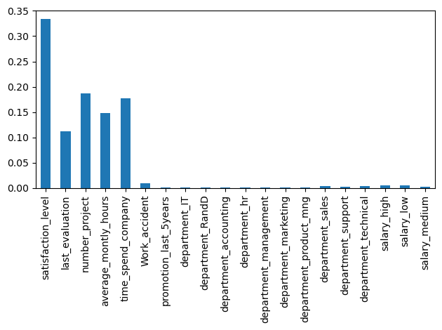

```python
importances = pd.Series(rf_best.feature_importances_, index=X_scaled.columns.tolist())

fig, ax = plt.subplots()
importances.plot.bar( ax=ax)
fig.tight_layout()
```

## Generalized Additive Model

GAMs are an extension of the generalized linear model framework, capable of capturing non-linear relationships between variables as well, making it very flexible. After playing around with the hyperparameters (partially see original file) I determined the best model. It has an accuracy of 0.92, not good, not terrible.

```python
# param_grid = {
#     's(0, n_splines': [10, 15, 20],
#     's(1)': [None, 5, 10],
#     's(2)': [None, 5, 10],
#     's(6)': [None, 5, 10],
#     's(8)': [None, 5, 10],
#     'te(5,8, n_splines': [(10, 10), (13, 13), (15, 15)]
# }
# cv = StratifiedKFold(n_splits=5, shuffle=True, random_state=42)
# gam = LogisticGAM()
# grid_search = GridSearchCV(estimator=gam, param_grid=param_grid, cv=cv, scoring='accuracy', verbose=1, n_jobs=-1)
# grid_search.fit(X_train, y_train)
# best_gam = grid_search.best_estimator_
# y_pred = best_gam.predict(X_test)
# gam_metrics = {
#     'Accuracy': accuracy_score(y_test, y_pred),
#     'Precision': precision_score(y_test, y_pred),
#     'Recall': recall_score(y_test, y_pred),
#     'F1 Score': f1_score(y_test, y_pred),
#     'ROC-AUC': roc_auc_score(y_test, y_pred)
# }


# print("Best Hyperparameters:", grid_search.best_params_)
# print("Best Cross-Validation Score:", grid_search.best_score_)
# print("Evaluation Metrics:", gam_metrics)
```

```python
gam = LogisticGAM(s(0, n_splines=15) + s(1) + s(2) + s(6)+ s(8)+ te(5,8, n_splines =[13,13])  ).fit(X_train, y_train)
y_pred_gam = gam.predict(X_test)
gam_metrics = {
    'Accuracy': accuracy_score(y_test, y_pred_gam),
    'Precision': precision_score(y_test, y_pred_gam),
    'Recall': recall_score(y_test, y_pred_gam),
    'F1 Score': f1_score(y_test, y_pred_gam),
    'ROC-AUC': roc_auc_score(y_test, y_pred_gam)
}
pd.DataFrame({'GAM':gam_metrics})
```

|  | GAM |
| --- | --- |
| Accuracy | 0.923712 |
| F1 Score | 0.833862 |
| Precision | 0.909931 |
| ROC-AUC | 0.872152 |
| Recall | 0.769531 |

It is a bit easier to compare it to the other models if we take a look at the confusion matrix. We can see that model is very good at finding true negative values, but since we are more interested in the true positive ones, choosing this GAM model would be suboptimal juxtaposed to the other ones.

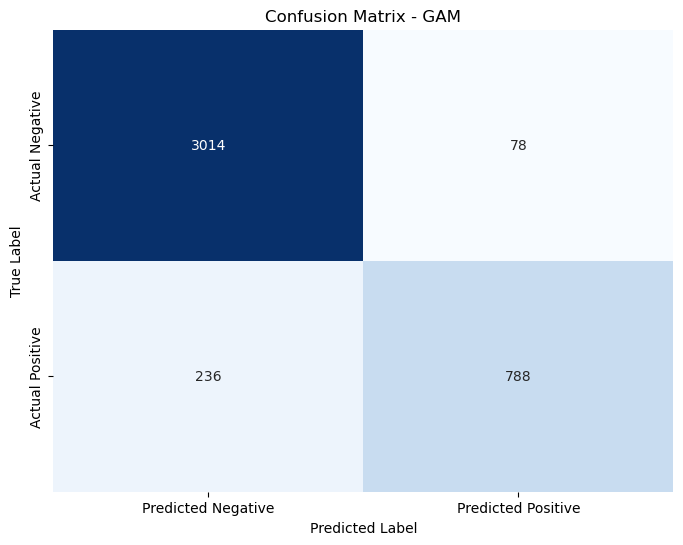

```python
conf_matrix_gam = confusion_matrix(y_test, y_pred_gam)
plt.figure(figsize=(8, 6))
sns.heatmap(conf_matrix_gam, annot=True, fmt='d', cmap='Blues', cbar=False,
            xticklabels=['Predicted Negative', 'Predicted Positive'],
            yticklabels=['Actual Negative', 'Actual Positive'])
plt.title('Confusion Matrix - GAM')
plt.xlabel('Predicted Label')
plt.ylabel('True Label')
plt.show()
```

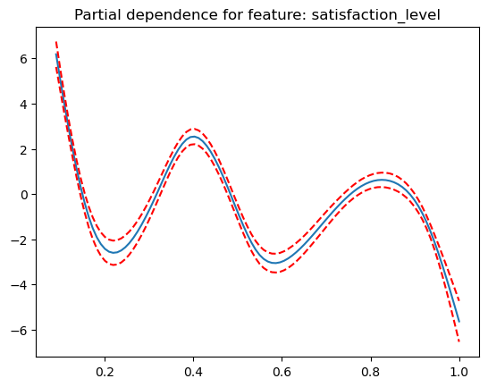

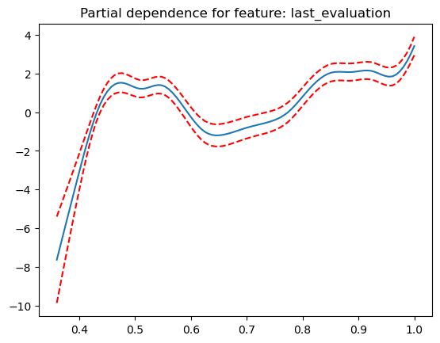

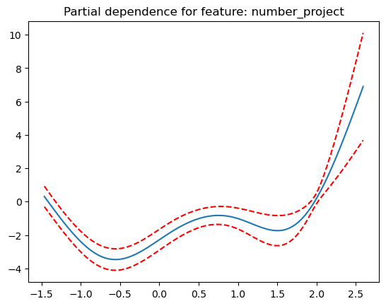

```python
f = X_train.columns.tolist()
features_to_exclude = ["average_montly_hours", "time_spend_company", "Work_accident"]





for i, term in enumerate(gam.terms):
    if term.isintercept:
        continue


    feature_name = f[i] if i < len(f) else f[-1]


    if feature_name not in features_to_exclude:
        XX = gam.generate_X_grid(term=i)
        pdep, confi = gam.partial_dependence(term=i, X=XX, width=0.95)

        plt.figure()
        plt.plot(XX[:, i], pdep)
        plt.plot(XX[:, i], confi, c='r', ls='--')
        plt.title(f'Partial dependence for feature: {feature_name}')
        plt.show()
```

## Conclusion

```python
#SVM
svm_report = classification_report(y_test, y_pred, output_dict=True)
svm_metrics = svm_report['1']

#GAM
gam_report = classification_report(y_test, y_pred_gam, output_dict=True)
gam_metrics = gam_report['1']  # Assuming you want metrics for class '1', adjust as needed

# Random Forest
rf_report = classification_report(y_test, y_pred_rf, output_dict=True)
rf_metrics = rf_report['1']

metrics_final_df = pd.DataFrame({
    'Model': ['GAM', 'SVM', 'Random Forest'],
    'Precision': [gam_metrics['precision'], svm_metrics['precision'], rf_metrics['precision']],
    'Recall': [gam_metrics['recall'], svm_metrics['recall'], rf_metrics['recall']],
    'F1-Score': [gam_metrics['f1-score'], svm_metrics['f1-score'], rf_metrics['f1-score']]
})
print("Evaluation metrics for finding quitting employees:")
print(metrics_final_df)
```

```
Evaluation metrics for finding quitting employees:
           Model  Precision    Recall  F1-Score
0            GAM   0.909931  0.769531  0.833862
1            SVM   0.953109  0.913086  0.932668
2  Random Forest   0.991935  0.960938  0.976190
```

All three models seem to be operating with a very high accuracy. From a pragmatic standpoint, we are mostly interested in identifying those employees who are the most likely to leave the company, and address their pain points. The most suitable model for this goal is the random forest, since it has the highest precision at finding these workers. As for the drivers of quitting, I failed to pinpoint anything that isn't already widely talked about in the organizational behaviour literature. While I'm quite sure, that these models are better at finding those playing with the idea of switching workplaces, they are not the solution for finding ways to retain them.

#### Disclosure

During the preparation of this work the author used ChatGPT from OpenAI in order to correct syntax mistakes in the python script. After using this tool/service, the author reviewed and edited the content as needed and takes full responsibility for the content of the publication.

#### References:

1: Kharwal, Aman : https://drive.google.com/file/d/1jEzDZX3XBPo-bebmioXtwk2aDehYrV8p/view

2: The Clever Programmer: Employee Turnover Prediction https://thecleverprogrammer.com/2020/07/12/employee-turnover-prediction/